# Recommender Systems

### Date : 12/05/2016

## Team :

[output not shown]

# Table of Content

### 1 . Load Libraries

### 2 . Load the Yelp dataset

#### 2.1 . Load the checkin data

#### 2.2 . Load the business data

#### 2.3 . Load the review data

#### 2.4 . Load the user data

#### 2.5 . Load the tips data

### 3 . Recommeder System Models

#### 3.1 . Popularity based recommender system

##### 3.1.1 . Train model

##### 3.1.1 . Recommend restaurants and predict ratings

##### 3.1.1 . Evaluate model

##### 3.1.1 . Deploy model

#### 3.2 . User - User collaborative filtering

##### 3.2.1 . Train model

##### 3.2.1 . Recommend restaurants and predict ratings

##### 3.3.1 . Evaluate model

##### 3.4.1 . Deploy model

#### 3.3 . Item - Item collaborative filtering

##### 3.3.1 . Train model

##### 3.3.1 . Recommend restaurants and predict ratings

##### 3.3.1 . Evaluate model

##### 3.3.1 . Deploy model

#### 3.4 . Content based recommender systems method

##### 3.4.1 . Generating restaurant attributes from reviews

##### 3.4.1.1 . Data preperation

##### 3.4.1.2 . Stemming and tokenizing the reviews

##### 3.4.1.3 . TF-IDF

##### 3.4.1.4 . Create a graphlab Sframe

##### 3.4.2 . Train model

##### 3.4.3 . Recommend restaurants and predict ratings

##### 3.4.3 . Evaluate model

##### 3.4.3 . Deploy model

#### 3.5 . Matrix factorization method

##### 3.5.1 . Train and optimize models

#### 3.6 . Matrix factorization with Factorization Machines

##### 3.6.1 . Train model

##### 3.6.1 . Recommend restaurants and predict ratings

##### 3.6.1 . Evaluate model

##### 3.6.1 . Deploy model

#### 3.7 . Ranking matrix factorization with Factorization Machines

##### 3.7.1 . Train model

##### 3.7.1 . Recommend restaurants and predict ratings

##### 3.7.1 . Evaluate model

##### 3.7.1 . Deploy model

### 4 . Comparing recommender system models

#### 4.1 . Next generation reccommender systems

##### 4.1.1 . Train model

##### 4.1.2 . Recommend restaurants and predict ratings

##### 4.1.3 . Evaluate model

##### 4.1.4 . Deploy model

### 5 . Comparing recommender system models

## 1. Load the necessary libraries and set working directory

```python
%matplotlib inline
# import necessary libraries and specify that graphs should be plotted inline.
import numpy as np
import pandas as pd
from pandas import Series,DataFrame
from IPython.display import display, HTML
import matplotlib.pyplot as plt
from matplotlib.colors import ListedColormap
from sklearn import preprocessing
import json
from pprint import pprint
import plotly.plotly as py
from plotly.tools import FigureFactory as FF
from ggplot import *
import plotly.graph_objs as go
import json
import graphlab as gl
```

```python
from sklearn.feature_extraction.text import TfidfVectorizer
from sklearn.feature_extraction.text import TfidfTransformer
from sklearn.feature_extraction.text import CountVectorizer
import pandas as pd
from pandas import Series,DataFrame
import nltk
import string
import os
from nltk.stem.porter import PorterStemmer
```

```python
import os;
os.chdir('C:/Users/surya/Google Drive/Predictive Analytics Project/Code/Datasets')
```

## 2. Load the Yelp dataset

##### *About the data*

- The Yelp dataset has been updated for Yelp dataset challenge 7. There are plenty of interesting insightswe can draw from this dataset.
- This set includes information about local businesses in 10 cities across 4 countries.
- There is a good combination of reviews, business attributes, check-ins, and tips, and open the door to even more exciting research.
- Each file is composed of a single object type, one json-object per-line.

#### *Below are the files which are loaded and used for our recommender systems project*

### 2.1 Load the checkin data

#### The json object looks like this : """ check-in { 'type': 'checkin', 'business_id': (encrypted business id), 'checkin_info': { '0-0': (number of checkins from 00:00 to 01:00 on all Sundays), '1-0': (number of checkins from 01:00 to 02:00 on all Sundays), ... '14-4': (number of checkins from 14:00 to 15:00 on all Thursdays), ... '23-6': (number of checkins from 23:00 to 00:00 on all Saturdays) }, # if there was no checkin for a hour-day block it will not be in the dict } """

```python
# Let us import the checking data
d = list()
with open('yelp_academic_dataset_checkin.json','r') as json_data:
    for line in json_data:
        d.append(json.loads(line))
checkin = DataFrame(d)
del d,json_data,line
```

```python
# we are extracting the number of checkins made by any user in a specific restaurant
checkin['tot_checkins'] = checkin['checkin_info'].apply(lambda a : sum(a.values()))
```

```python
# sneak peak into the checkin data
checkin.head(5)
```

|  | business_id | checkin_info | type | tot_checkins |
| --- | --- | --- | --- | --- |
| 0 | cE27W9VPgO88Qxe4ol6y_g | {u'9-5': 1, u'7-5': 1, u'13-3': 1, u'17-6': 1,... | checkin | 9 |
| 1 | mVHrayjG3uZ_RLHkLj-AMg | {u'11-5': 1, u'9-5': 2, u'9-4': 3, u'15-1': 1,... | checkin | 28 |
| 2 | mYSpR_SLPgUVymYOvTQd_Q | {u'5-5': 1, u'5-4': 1, u'9-3': 1, u'11-4': 1, ... | checkin | 8 |
| 3 | KayYbHCt-RkbGcPdGOThNg | {u'23-1': 1, u'11-2': 2, u'21-4': 1, u'16-1': ... | checkin | 65 |
| 4 | b12U9TFESStdy7CsTtcOeg | {u'5-5': 2, u'13-2': 1, u'8-6': 1, u'5-1': 2, ... | checkin | 7 |

### 2.2 Load the business data

#### The json object looks like this : business { 'type': 'business', 'business_id': (encrypted business id), 'name': (business name), 'neighborhoods': [(hood names)], 'full_address': (localized address), 'city': (city), 'state': (state), 'latitude': latitude, 'longitude': longitude, 'stars': (star rating, rounded to half-stars), 'review_count': review count, 'categories': [(localized category names)] 'open': True / False (corresponds to closed, not business hours), 'hours': { (day_of_week): { 'open': (HH:MM), 'close': (HH:MM) }, ... }, 'attributes': { (attribute_name): (), ... },

```python
# Let us import the checking data
d = list()
with open('yelp_academic_dataset_business.json','r') as json_data:
    for line in json_data:
        d.append(json.loads(line))
business = DataFrame(d)
del d,json_data,line
```

```python
def find_rest(a_list,x):
    res = [y for y in a_list if x in y]
    if len(res) >= 1:
        return True
    else:
        return False
```

```python
# This data contains many business like restaurants, shops, malls etc. As we are only interested in restaurant recommender
# Filtering restaurant data into a new dataframe
restaurants = business[business['categories'].apply(lambda a : find_rest(a,'Restaurants'))].reset_index()
restaurants = restaurants.drop('index',axis=1)
```

```python
restaurants = pd.merge(restaurants,checkin[['business_id','tot_checkins']])
```

```python
restaurants.head(2)
```

|  | attributes | business_id | categories | city | full_address | hours | latitude | longitude | name | neighborhoods | open | review_count | stars | state | type | tot_checkins |
| --- | --- | --- | --- | --- | --- | --- | --- | --- | --- | --- | --- | --- | --- | --- | --- | --- |
| 0 | {u'Alcohol': u'full_bar', u'Noise Level': u'av... | mVHrayjG3uZ_RLHkLj-AMg | [Bars, American (New), Nightlife, Lounges, Res... | Braddock | 414 Hawkins Ave\nBraddock, PA 15104 | {u'Tuesday': {u'close': u'19:00', u'open': u'1... | 40.408830 | -79.866211 | Emil's Lounge | [] | True | 26 | 4.5 | PA | business | 28 |
| 1 | {u'Alcohol': u'full_bar', u'Noise Level': u'lo... | KayYbHCt-RkbGcPdGOThNg | [Bars, American (Traditional), Nightlife, Rest... | Carnegie | 141 Hawthorne St\nGreentree\nCarnegie, PA 15106 | {u'Monday': {u'close': u'02:00', u'open': u'11... | 40.415486 | -80.067549 | Alexion's Bar & Grill | [Greentree] | True | 23 | 4.0 | PA | business | 65 |

```python
# The table has some columns which have a comlex json structure.
# Using the below fuction we can get various restaurant attributes from the attributes column.
def get_restaurant_attr(a_json,column):
    if column == 'Ambience':
        if column in a_json.keys():
            return sum(a_json[column].values())
    if column == 'Good For':
        if column in a_json.keys():
            if sum(a_json[column].values()) > 0 : return 1
            else : return 0
    if column == 'Parking':
        if column in a_json.keys():
            return sum(a_json[column].values())
    elif column in a_json.keys():
        return a_json[column]
    else:
        return 'N/A'
```

```python
restaurants['Acc_credit_card'] = restaurants['attributes'].apply(lambda x : get_restaurant_attr(x,'Accepts Credit Cards'))
restaurants['Alcohol'] = restaurants['attributes'].apply(lambda x : get_restaurant_attr(x,'Alcohol'))
restaurants['Ambience'] = restaurants['attributes'].apply(lambda x : get_restaurant_attr(x,'Ambience'))
restaurants['Delivery'] = restaurants['attributes'].apply(lambda x : get_restaurant_attr(x,'Delivery'))
restaurants['Good For'] = restaurants['attributes'].apply(lambda x : get_restaurant_attr(x,'Good For'))
restaurants['Parking'] = restaurants['attributes'].apply(lambda x : get_restaurant_attr(x,'Parking'))
restaurants['Price Range'] = restaurants['attributes'].apply(lambda x : get_restaurant_attr(x,'Price Range'))
restaurants['Take-out'] = restaurants['attributes'].apply(lambda x : get_restaurant_attr(x,'Take-out'))
restaurants['Takes Reservations'] = restaurants['attributes'].apply(lambda x : get_restaurant_attr(x,'Takes Reservations'))
restaurants['Waiter Service'] = restaurants['attributes'].apply(lambda x : get_restaurant_attr(x,'Waiter Service'))
restaurants['Noise Level'] = restaurants['attributes'].apply(lambda x : get_restaurant_attr(x,'Noise Level'))
restaurants['Outdoor Seating'] = restaurants['attributes'].apply(lambda x : get_restaurant_attr(x,'Outdoor Seating'))
```

```python
# Smapling data for geerating recommendation on Las Vegas
restaurants_LV = restaurants[restaurants['city'].str.contains('Las Vegas')]
```

```python
restaurants_LV.to_csv('restaurants_LV.csv',encoding='utf-8')
```

```python
# Dropping unneccesary columns while createing SFrame to reduce load on the algorithm

df1 = restaurants_LV.drop(['attributes','categories','full_address','hours','latitude','longitude',\
                                             'neighborhoods','state','type','city','open'],axis=1).reset_index()
df1 = df1.drop(['index'],axis=1)

# Imputing missing values with mode before converting to SFrame

df1.Acc_credit_card = np.where(df1.Acc_credit_card=='N/A',False,df1.Acc_credit_card)
df1.Alcohol = np.where(df1.Alcohol=='N/A','none',df1.Alcohol)
df1.Ambience = np.where(df1.Ambience=='N/A',np.nan,df1.Ambience)
df1['Good For'] = np.where(df1['Good For'] =='N/A',np.nan,df1['Good For'])
df1['Delivery'] = np.where(df1['Delivery'] =='N/A',False,df1['Delivery'])
df1['Price Range'] = np.where(df1['Price Range']=='N/A',np.nan,df1['Price Range'])
df1['Take-out'] = np.where(df1['Take-out']=='N/A',np.nan,df1['Take-out'])
df1['Takes Reservations'] = np.where(df1['Takes Reservations']=='N/A',False,\
                                                df1['Takes Reservations'])
df1['Waiter Service'] = np.where(df1['Waiter Service']=='N/A',False,df1['Waiter Service'])
df1['Noise Level'] = np.where(df1['Noise Level']=='N/A','average',df1['Noise Level'])
df1['Outdoor Seating'] = np.where(df1['Outdoor Seating']=='N/A',False,df1['Outdoor Seating'])
```

```python
# creating an Sframe object for using graphlab package
restaurants_LV_sf = gl.SFrame(df1)
```

[output not shown]

[output not shown]

```python
restaurants_LV_sf.head()
```

| business_id | name | review_count | stars | tot_checkins | Acc_credit_card | Alcohol |
| --- | --- | --- | --- | --- | --- | --- |
| JNArUYl2aVBHNNi6hXcG8g | Rigos Taco | 21 | 3.5 | 65 | 1 | none |
| eihJZqHCEKMmzuPOOyqF9w | Mulligans Bar & Grill | 10 | 4.0 | 28 | 1 | full_bar |
| n1f9rWJzdGX982bFvZPBHg | Carl's Jr Restaurants | 7 | 2.5 | 39 | 1 | none |
| i7HvZ1yTTIaR6bfa_3jGEw | KFC | 8 | 2.0 | 6 | 1 | none |
| NkmE03gbKjSdqDM3SJsJmw | Church's Chicken | 3 | 1.5 | 3 | 1 | none |
| KBP-RXCaDQwfMP_-TLwuFg | Sonic Drive-In | 37 | 3.0 | 218 | 1 | none |
| hvVckRvOa814ry8q8WGwOg | Burger King | 4 | 3.5 | 37 | 1 | none |
| THEsYolDkHaJofZLs6ufWg | Jack In the Box | 12 | 3.0 | 74 | 1 | none |
| rG_8t33D2ADcbBqcXqwV0Q | Viva Zapatas Mexican Restaurant & Cantina ... | 443 | 4.0 | 990 | 1 | full_bar |
| _OyxUcWkSTRvRKFyEE7zbA | Tortas El Rey | 11 | 3.0 | 21 | 1 | none |

| Ambience | Delivery | Good For | Parking | Price Range | Take-out | Takes Reservations | Waiter Service | Noise Level |
| --- | --- | --- | --- | --- | --- | --- | --- | --- |
| 1.0 | 0 | 1.0 | 1.0 | 1.0 | 1.0 | 0 | 0 | average |
| 1.0 | 0 | 0.0 | 1.0 | 2.0 | 1.0 | 1 | 1 | average |
| nan | 0 | 0.0 | 0.0 | 1.0 | 1.0 | 0 | 0 | average |
| nan | 0 | nan | nan | 1.0 | 1.0 | 0 | 0 | very_loud |
| nan | 0 | 0.0 | 0.0 | 1.0 | 1.0 | 0 | 0 | average |
| 1.0 | 0 | 1.0 | 1.0 | 1.0 | 1.0 | 0 | 1 | average |
| 0.0 | 0 | 0.0 | 0.0 | 1.0 | 1.0 | 0 | 0 | average |
| 0.0 | 0 | 0.0 | nan | 1.0 | 1.0 | 0 | 0 | quiet |
| 1.0 | 0 | 1.0 | 1.0 | 2.0 | 1.0 | 1 | 1 | average |
| 1.0 | 0 | 1.0 | 1.0 | 1.0 | 1.0 | 0 | 0 | average |

| Outdoor Seating |
| --- |
| 1 |
| 0 |
| 0 |
| 0 |
| 0 |
| 1 |
| 0 |
| 0 |
| 0 |
| 1 |

[10 rows x 17 columns]

```python
restaurants_LV_sf_mf = restaurants_LV_sf.dropna()
```

```python
del df1,checkin
```

### 2.3 Load the review data

```python
d = list()
with open('yelp_academic_dataset_review.json','r') as json_data:
    for line in json_data:
        d.append(json.loads(line))
review = DataFrame(d)
del d,json_data,line
```

```python
review['useful'] = review['votes'].apply(lambda a : a['useful'])
review['funny'] = review['votes'].apply(lambda a : a['funny'])
review['cool'] = review['votes'].apply(lambda a : a['cool'])
```

```python
review_LV = pd.merge(review,restaurants_LV[['business_id','name']], on='business_id')
```

```python
review_LV.to_csv('review_LV.csv',encoding='utf-8')
```

```python
# Normalizing user and item reviws to remove the scaling error
def  user_normalize_ratings(df):
    mean_rt = DataFrame({'avg_stars_user' : df.groupby( ['user_id'])['stars'].mean()}).reset_index()
    df = pd.merge(df,mean_rt,on='user_id')
    df['user_normalized_stars'] = df['stars']- df['avg_stars_user']
    return df
```

```python
# Normalizing user and item reviws to remove the scaling error
def  item_normalize_ratings(df):
    mean_rt = DataFrame({'avg_stars_items' : df.groupby( ['business_id'])['stars'].mean()}).reset_index()
    df = pd.merge(df,mean_rt,on='business_id')
    df['item_normalized_stars'] = df['stars']- df['avg_stars_items']
    return df
```

```python
review_LV_norm = review_LV[['business_id', 'user_id','stars','name']]
review_LV_norm = user_normalize_ratings(review_LV_norm)
review_LV_norm = item_normalize_ratings(review_LV_norm)
```

```python
# Take a sneak peak into the data
review_LV_norm.head(2)
```

|  | business_id | user_id | stars | name | avg_stars_user | user_normalized_stars | avg_stars_items | item_normalized_stars |
| --- | --- | --- | --- | --- | --- | --- | --- | --- |
| 0 | JNArUYl2aVBHNNi6hXcG8g | f5vgLcoKpFcTvD4lOUxcTQ | 2 | Rigos Taco | 3.355372 | -1.355372 | 3.529412 | -1.529412 |
| 1 | JNArUYl2aVBHNNi6hXcG8g | MWw9-Eo1AQuJpdTbZ13vlw | 5 | Rigos Taco | 4.000000 | 1.000000 | 3.529412 | 1.470588 |

```python
review_LV_norm.to_csv('review_LV_norm.csv',encoding='utf-8')
```

```python
review_LV_norm_sf = gl.SFrame(review_LV_norm)
```

```python
del review
```

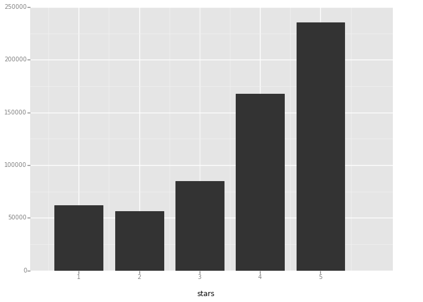

```python
#The distribution of the dependent variable
ggplot(review_LV, aes(x='stars')) + geom_bar()
```

### 2.4 Load the user data

```python
d = list()
with open('yelp_academic_dataset_user.json','r') as json_data:
    for line in json_data:
        d.append(json.loads(line))
user = DataFrame(d)
del d,json_data,line
```

```python
user['useful'] = user['votes'].apply(lambda a : a['useful'])
user['funny'] = user['votes'].apply(lambda a : a['funny'])
user['cool'] = user['votes'].apply(lambda a : a['cool'])
```

```python
user.head(2)
```

|  | average_stars | compliments | elite | fans | friends | name | review_count | type | user_id | votes | yelping_since | useful | funny | cool |
| --- | --- | --- | --- | --- | --- | --- | --- | --- | --- | --- | --- | --- | --- | --- |
| 0 | 4.14 | {u'profile': 8, u'cute': 15, u'funny': 11, u'p... | [2005, 2006] | 69 | [rpOyqD_893cqmDAtJLbdog, 4U9kSBLuBDU391x6bxU-Y... | Russel | 108 | user | 18kPq7GPye-YQ3LyKyAZPw | {u'funny': 167, u'useful': 282, u'cool': 246} | 2004-10 | 282 | 167 | 246 |
| 1 | 3.67 | {u'profile': 117, u'cute': 204, u'funny': 594,... | [2005, 2006, 2007, 2008, 2009, 2010, 2011, 201... | 1345 | [18kPq7GPye-YQ3LyKyAZPw, 4U9kSBLuBDU391x6bxU-Y... | Jeremy | 1292 | user | rpOyqD_893cqmDAtJLbdog | {u'funny': 8399, u'useful': 15242, u'cool': 12... | 2004-10 | 15242 | 8399 | 12091 |

```python
user_lv = user[user['user_id'].isin(review_LV_norm['user_id'].unique())]
```

```python
user_lv.to_csv('user_lv.csv',encoding='utf-8')
```

```python
user_lv_sf = gl.SFrame(user_lv)
```

```python
user_lv_sf_mf =  user_lv_sf.select_columns(['average_stars','fans','name','review_count',\
                                            'user_id','yelping_since','useful','funny','cool'])
```

### 2.5 Load the tips data

```python
d = list()
with open('yelp_academic_dataset_tip.json','r') as json_data:
    for line in json_data:
        d.append(json.loads(line))
tips = DataFrame(d)
del d,json_data,line
```

```python
tips.head(10)
```

|  | business_id | date | likes | text | type | user_id |
| --- | --- | --- | --- | --- | --- | --- |
| 0 | 5UmKMjUEUNdYWqANhGckJw | 2016-07-17 | 0 | Pizza is garbage. Hoagies are excellent. | tip | ZxdojCZgZhw36xuSGaryRg |
| 1 | cE27W9VPgO88Qxe4ol6y_g | 2013-04-18 | 0 | Don't waste your time. | tip | -6rEfobYjMxpUWLNxszaxQ |
| 2 | mVHrayjG3uZ_RLHkLj-AMg | 2016-02-22 | 0 | Not easy to find. Be sure to put in directions... | tip | 5OumCBQ_MyQsltSdbMyunA |
| 3 | mVHrayjG3uZ_RLHkLj-AMg | 2013-01-06 | 1 | Your GPS will not allow you to find this place... | tip | EZ0r9dKKtEGVx2CdnowPCw |
| 4 | KayYbHCt-RkbGcPdGOThNg | 2013-12-03 | 0 | Great drink specials! | tip | xb6zEQCw9I-Gl0g06e1KsQ |
| 5 | KayYbHCt-RkbGcPdGOThNg | 2015-07-08 | 0 | Friendly staff, good food, great beer selectio... | tip | QawZN4PSW7ng_9SP7pjsVQ |
| 6 | KayYbHCt-RkbGcPdGOThNg | 2016-02-18 | 0 | Fantastic! Great food, excellent beer selectio... | tip | 8K8qHAH9AREKxIIZAwQ9Fg |
| 7 | KayYbHCt-RkbGcPdGOThNg | 2016-05-05 | 0 | I love this place! Great prices, great food, g... | tip | U3VIAqv7eaCCorYsVCRCHA |
| 8 | 1_lU0-eSWJCRvNGk78Zh9Q | 2015-10-25 | 0 | Beautiful restoration. | tip | MLQre1nvUtW-RqMTc4iC9A |
| 9 | 1_lU0-eSWJCRvNGk78Zh9Q | 2015-01-06 | 0 | Home to Stage 62 theatre group. | tip | bvu13GyOUwhEjPum2xjiqQ |